# *Topic : Binary Classification using Logisitic Regression*

##### Programing Language : Python

##### Created by : Devashish Dhiman

## Introduction to Logisitic Regression

Like many other machine learning techniques, it is borrowed from the field of statistics and despite its name, it is not an algorithm for regression problems, where you want to predict a continuous outcome. Instead, Logistic Regression is the go-to method for binary classification. It gives you a discrete binary outcome between 0 and 1. To say it in simpler words, it’s outcome is either one thing or another.

Logistic can be categorised as;

- Linear Algorithm
- Classification Algorithm
- [Supervised machine learning algorithm](https://youtu.be/HE-5061-4pE)
- [Parameteric Algorithm](https://youtu.be/UgwUi8fu0CY)

## Why to use Logisitc Regression?

In a previous video we understood how Linear regression works and how we can use it to predict continous Y variable.

[Youtube : Linear Regression](https://youtu.be/RDDeJa8-O9c)

In linear regression the Y variable is always a continuous variable. If suppose, the Y variable was categorical, you cannot use linear regression model it.

*So what would you do when the Y is a categorical variable with 2 classes?*

**Logistic regression can be used to model and solve such problems, also called as binary classification problems.**

Let's take an example of student test score to understand this better.

- **Linear Regression** could help us predict the student’s test score on a scale of 0 - 100. Linear regression predictions are continuous.
- **Logistic Regression** could help use predict whether the student passed or failed. Logistic regression predictions are discrete.

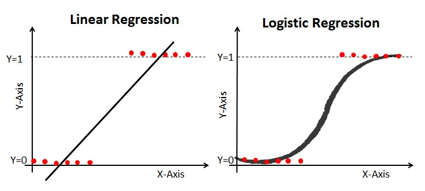

## How Does it work?

Logistic Regression measures the relationship between the dependent variable (our label, what we want to predict) and the one or more independent variables (our features), by estimating probabilities using it’s underlying logistic function.

These probabilities must then be transformed into binary values in order to actually make a prediction. This is the task of the logistic function, also called the sigmoid function. The Sigmoid-Function is an S-shaped curve that can take any real-valued number and map it into a value between the range of 0 and 1, but never exactly at those limits. This values between 0 and 1 will then be transformed into either 0 or 1 using a threshold classifier.

The picture below illustrates the steps that logistic regression goes through to give you your desired output.

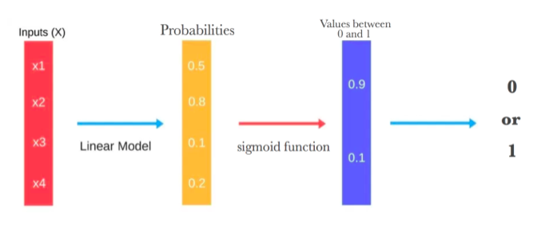

*Picture Credit : https://machinelearning-blog.com/*

We want to maximize the likelihood that a random data point gets classified correctly, which is called **Maximum Likelihood Estimation**. *You can maximize the likelihood using an optimization algorithm like Newton’s Method or Gradient Descent.*

##### Mathematics of Logisitic Regression : StatQuest - https://youtu.be/yIYKR4sgzI8

### *Advantages & Disadvantages*

#### Advantages

- It is extremely efficient
- Does not require much resources
- Very fast training and prediction times
- Easy to interpret
- Does not require inputs to be scalled
- Easy to regularise

#### Disadvantages

- It can only be used for linear problems
- You would have to supervise the input variables and remove the unrelated independent variables
- Can only predict a categorical outcome
- Tends to overfit

## What can it be used for?

You might wonder what kind of problems you can use logistic regression for. It is the most widly used Algorithm of all.

Here are some examples of binary classification problems:

1. **Spam Detection** : Predicting if an email is Spam or not
2. **Banking** : Predicting if a customer will default on a loan.
3. **Marketing** : Predicting if a given user will buy an insurance product or not
4. **Credit Card Fraud** : Predicting if a given credit card transaction is fraud or not
5. **Health** : Predicting if a patient has diabetes or not
6. **Survival** : Predicting if a passenger would survive the titanic (sort of) event

# **Logisitc Regression Tutorial**

#### *Loading the data*

Open Data sources

1. Google Dataset Search
2. UCL Library
3. Data.world

Dictionary - https://data.world/exercises/logistic-regression-exercise-1

```python
import pandas as pd
import numpy as np
from sklearn.linear_model import LogisticRegression

#Import Packages for Model Validation
from sklearn.metrics import classification_report
from sklearn.metrics import precision_score
from sklearn.metrics import accuracy_score
from sklearn.metrics import recall_score
from sklearn.metrics import roc_curve
from sklearn.metrics import confusion_matrix
from sklearn.metrics import precision_recall_curve
from sklearn.model_selection import train_test_split
from yellowbrick.classifier import ROCAUC
from yellowbrick.classifier import PrecisionRecallCurve
from yellowbrick.classifier import ClassificationReport
from yellowbrick.classifier import ClassPredictionError
from yellowbrick.classifier import DiscriminationThreshold
from yellowbrick.classifier import ConfusionMatrix
from yellowbrick.classifier import ClassBalance
from sklearn.preprocessing import scale
from scipy import stats
import warnings
import statsmodels.api as sm
warnings.simplefilter(action='ignore', category=FutureWarning)
```

```python
data = pd.read_csv("Social_Network_Ads.csv")
```

#### *Data exploration and Visualisation*

```python
data.head()
```

|  | User ID | Gender | Age | EstimatedSalary | Purchased |
| --- | --- | --- | --- | --- | --- |
| 0 | 15624510 | Male | 19 | 19000 | 0 |
| 1 | 15810944 | Male | 35 | 20000 | 0 |
| 2 | 15668575 | Female | 26 | 43000 | 0 |
| 3 | 15603246 | Female | 27 | 57000 | 0 |
| 4 | 15804002 | Male | 19 | 76000 | 0 |

```python
data.describe()
```

|  | User ID | Age | EstimatedSalary | Purchased |
| --- | --- | --- | --- | --- |
| count | 4.000000e+02 | 400.000000 | 400.000000 | 400.000000 |
| mean | 1.569154e+07 | 37.655000 | 69742.500000 | 0.357500 |
| std | 7.165832e+04 | 10.482877 | 34096.960282 | 0.479864 |
| min | 1.556669e+07 | 18.000000 | 15000.000000 | 0.000000 |
| 25% | 1.562676e+07 | 29.750000 | 43000.000000 | 0.000000 |
| 50% | 1.569434e+07 | 37.000000 | 70000.000000 | 0.000000 |
| 75% | 1.575036e+07 | 46.000000 | 88000.000000 | 1.000000 |
| max | 1.581524e+07 | 60.000000 | 150000.000000 | 1.000000 |

```python
## Transforming the Purchased into factor
data['Purchased'] = data.Purchased.astype("category")
data['Gender'] = data['Gender'].str.replace('Male','0').str.replace('Female','1')
data['Gender'] = data.Gender.astype("int")
data.Purchased.head()
data.Gender.head()
```

```
0    0
1    0
2    1
3    1
4    0
Name: Gender, dtype: int64
```

#### *Spliting the dataset into Training and Test dataset*

```python
# Splitting the dataset into the Training set and Test set
X = data.iloc[:, [2, 3]].values
y = data['Purchased']
X_train,X_test,y_train,y_test = train_test_split(X,y,test_size=0.25)
```

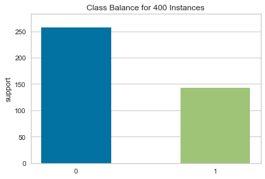

```python
lr_visualizer = ClassBalance()
lr_visualizer.fit(y)
lr_visualizer.poof()
```

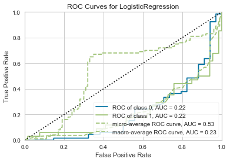

```python
#ROCAUC Curve
lr_classification = LogisticRegression(max_iter=2000)
lr_visualizer = ROCAUC(lr_classification)
lr_visualizer.fit(X_train, y_train)
lr_visualizer.score(X_test, y_test)
lr_visualizer.poof()
```

```python
#Logistic Regression
lr_classification = LogisticRegression(max_iter=2000)
lr_classification.fit(X_train,y_train)
y_pred = lr_classification.predict(X_test)
cm = confusion_matrix(y_test, y_pred)
#print(cm)
```

```python
n = X_test.shape[0]
pred = pd.DataFrame(data=y_pred) #predict the probabilities
pred['predicted class'] = pred.idxmax(axis=1) #identify the class with the highest probability
pred['actual class'] = y_test #fill in the actual class from the test data
pred['predicted class'] = pd.to_numeric(pred['predicted class']) #convert class to numeric
pred['actual class'] = pd.to_numeric(pred['actual class'])
pred['error'] = np.where((pred['predicted class'] != pred['actual class']), 1, 0)

print("number of errors:", pred['error'].sum())
print("accuracy:", (1-pred['error'].sum()/n)*100)
```

```
number of errors: 74
accuracy: 26.0
```

##### Lets understand what these numbers mean

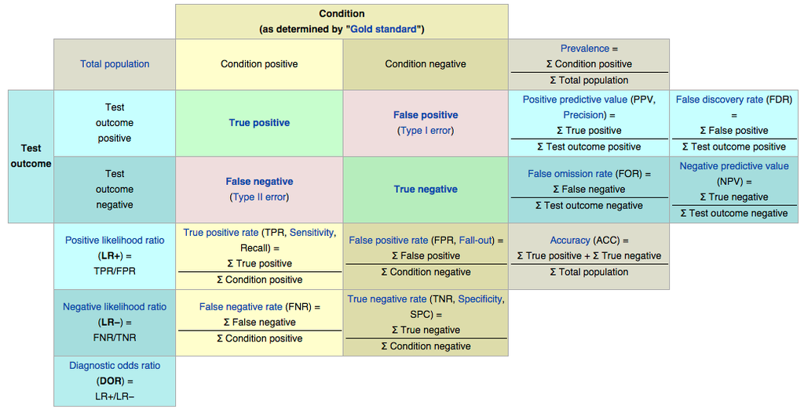